# A Comprehensive Workflow for 10x Genomics Xenium Data Analysis using Seurat

**Authors:** M. van Baardwijk, R. Benaiges-Fernandez, JF Sanchez-Herrero, L. Sumoy, …

This tutorial outlines a spatial transcriptomics workflow using 10x Genomics Xenium data and the Seurat package in R. It covers data loading, quality control, exploration, normalization, dimensionality reduction, clustering, and cluster annotation.

## Introduction to Spatial Transcriptomics and Xenium Data

Spatial transcriptomics is a groundbreaking set of technologies that allows scientists to measure gene expression within a tissue sample while preserving the critical spatial information. Unlike traditional bulk RNA sequencing, which homogenizes tissue and loses spatial context, or single-cell RNA sequencing, which dissociates cells and discards their original locations, spatial transcriptomics provides insights into how gene expression varies across different regions of a tissue and how cells interact within their native microenvironment. This is particularly valuable for understanding complex biological processes, disease progression, and the cellular organization of tissues.

**10x Genomics Xenium In Situ** is a high-resolution spatial transcriptomics technology that enables the direct measurement of RNA molecules within tissue sections at subcellular resolution. This means that not only can individual cells be identified, but the precise locations of specific RNA transcripts within those cells are also recorded. The output from a Xenium run is comprehensive and typically includes several key files essential for downstream computational analysis:

- `cell_boundaries.csv.gz`: This gzipped CSV file contains the precise polygonal coordinates that define the boundaries of each identified cell in the tissue section. These boundaries are crucial for segmenting cells and assigning transcripts to individual cells.
- `cells.csv.gz`: This gzipped CSV file provides detailed information about each identified cell, including its unique identifier, spatial coordinates (e.g., centroid), and various morphological or quality metrics.
- `transcripts.csv.gz`: This gzipped CSV file lists every detected RNA transcript molecule, including its gene identity, precise x and y spatial coordinates, and the cell to which it was assigned (if applicable). This is the core data for gene expression quantification.
- `cell_feature_matrix/`: This is a directory that typically contains three gzipped files that collectively represent the gene expression matrix for each cell:
  - `barcodes.tsv.gz`: Lists the unique cell barcodes (identifiers).
  - `features.tsv.gz`: Lists the genes (features) measured.
  - `matrix.mtx.gz`: The actual sparse matrix containing the raw transcript counts for each gene in each cell.

**Seurat** is an immensely popular and powerful R package that was originally developed for the analysis of single-cell RNA sequencing (scRNA-seq) data. It has since been extensively developed to support various multi-modal and spatial transcriptomics datasets, including those from 10x Genomics Xenium. Seurat provides a comprehensive suite of functions for every step of the analysis pipeline, including:

- **Data integration**: Combining data from multiple samples or technologies.
- **Visualization**: Generating various plots to explore data and results.
- **Quality control**: Filtering out low-quality cells or artifacts.
- **Normalization**: Adjusting for technical variations in sequencing depth.
- **Dimensionality reduction**: Reducing the complexity of high-dimensional gene expression data (e.g., PCA, UMAP).
- **Clustering**: Grouping similar cells into distinct populations.
- **Differential expression analysis**: Identifying genes that are uniquely expressed or significantly different between cell populations.

## Setting up the Environment and Loading Data

First of all, we need to open an interactive Rstudio session in galaxy. To that purpose, we can follow this tutorial. **Rstudio in Galaxy** `https://training.galaxyproject.org/training-material/topics/galaxy-interface/tutorials/rstudio/tutorial.html` The initial steps in any spatial transcriptomics analysis involve preparing the R environment by loading necessary libraries and then importing the raw Xenium data into a structured format suitable for analysis, such as a Seurat object. Since this tutorial focuses on the use of an interactive session of Rstudio in the galaxy servers, the step of installing the required packages may not be necessary.

### Loading Required R Packages

Before any data processing can begin, we must load the necessary R packages. Each package serves a specific purpose in our workflow:

- `Seurat`: The core package for single-cell and spatial transcriptomics data analysis. It provides the primary data structure (`Seurat object`) and functions for most analytical steps.
- `ggplot2`: A versatile and widely used package for creating highly customized and aesthetically pleasing data visualizations in R. Many Seurat plotting functions leverage `ggplot2` internally.
- `patchwork`: This package simplifies the arrangement and combination of multiple `ggplot2` plots into a single, cohesive layout. This is particularly useful for presenting various visualizations together.
- `dplyr`: Part of the `tidyverse` suite, `dplyr` provides a powerful and intuitive grammar for data manipulation. It is used for filtering, grouping, and transforming data frames, which is often necessary when working with metadata or differential gene expression results.

```r
# Load required packages
library(Seurat)
library(ggplot2)
library(patchwork)
library(dplyr)
```

### Loading Xenium Output Data

The next crucial step is to load the raw Xenium data into R. The 10x Genomics Xenium platform produces a specific set of output files, and the `LoadXenium` function in Seurat is designed to parse these files efficiently and construct a Seurat object. In this tutorial we use `Non_diseased_lung_minimal` dataset, this is a subset of the healthy tissue of the `Post-Xenium Technical Note: Xenium v1 and Xenium Prime 5K for FFPE Human Lung Cancer` provided in the 10x Genomics database. `https://www.10xgenomics.com/datasets/preview-data-ffpe-human-lung-cancer-with-xenium-multimodal-cell-segmentation-1-standard`. You can get this dataset as it is available in the 10x Genomics website.

```r
wget https://cf.10xgenomics.com/samples/xenium/2.0.0/Xenium_V1_humanLung_Cancer_FFPE/Xenium_V1_humanLung_Cancer_FFPE_outs.zip
wget https://cf.10xgenomics.com/samples/xenium/2.0.0/Xenium_V1_humanLung_Cancer_FFPE/Xenium_V1_humanLung_Cancer_FFPE_xe_outs.zip
```

In a Galaxy environment, input files are typically accessed via specific paths provided by the `gx_get()` function.

1. `gx_get(1)`: This command retrieves the file path for the first input dataset, which in this case is expected to be a zipped archive containing all the Xenium machine output files.
2. `unzip("/import/1")`: Once the path is retrieved, this command unzips the archive into a directory. The `LoadXenium` function expects an unzipped directory containing the Xenium output files.
3. `xenium.obj <- LoadXenium("Non_diseased_lung_minimal")`: This function reads the various Xenium files (e.g., `cell_boundaries.csv.gz`, `cells.csv.gz`, `transcripts.csv.gz`, and the `cell_feature_matrix` directory) from the specified directory (`"Non_diseased_lung_minimal"`) and creates a Seurat object. This object will contain the gene expression data, spatial coordinates, cell boundaries, and associated metadata.
4. `xenium.obj <- subset(xenium.obj, subset = nCount_Xenium > 0)`: After loading, it’s a common quality control step to remove cells that have zero detected transcript counts (`nCount_Xenium`). These cells are typically artifacts or dead cells and do not contribute meaningful biological information. Subsetting ensures that only cells with actual gene expression data are retained for downstream analysis.

```r
gx_get(1) # Retrieve the file path for the zipped Xenium machine output
unzip("/import/1") # Unzip the Xenium output
xenium.obj <- LoadXenium("Non_diseased_lung_minimal")
xenium.obj <- subset(xenium.obj, subset = nCount_Xenium > 0) # remove cells with 0 counts
```

**Important Note for Non-Galaxy Users:** If you are running this R Markdown script outside of the Galaxy environment, you will need to replace the `gx_get(1)` and `unzip("/import/1")` lines with commands that manually specify the path to your unzipped Xenium data directory. For example:

```r
# For non-Galaxy environments:
# xenium_data_dir <- "path/to/your/unzipped/xenium_output_directory"
# xenium.obj <- LoadXenium(xenium_data_dir)
# xenium.obj <- subset(xenium.obj, subset = nCount_Xenium > 0)
```

### Loading Gene Panel Annotation

In addition to the Xenium expression data, 10x Genomics often provides a gene panel information file. This file contains valuable annotations for the genes included in the Xenium assay, such as their associated cell types or functional categories. This annotation data will be critical later on for interpreting the identified clusters and assigning biological cell type labels. In our case, the gene panel used is the **Xenium Human Multi-Tissue and Cancer Panel**, which includes **377 genes**. This panel was **pre-designed by 10x Genomics** using **single-cell RNA sequencing data** curated and reprocessed by the **Human Protein Atlas** to ensure standardization. The genes were selected to enable accurate cell typing and to identify key **immune, proliferation, and tumor markers** across various tissues, including **breast, lung, skin, liver, colon, kidney, lung cancer, and heart**.

1. `gx_get(2)`: In Galaxy, this retrieves the file path for the second input geme annotation data, which is expected to be the gene panel annotation file (e.g., a CSV file).
2. `anno.dat <- read.csv("/import/2")`: This command reads the CSV file into an R data frame named `anno.dat`. This data frame typically contains columns like “Gene” and “Annotation,” which will be used for mapping genes to cell types.

```r
gx_get(2) # Retrieve the file path for the gene pannel annotation
anno.dat <- read.csv("/import/2")
```

**Important Note for Non-Galaxy Users:** Similar to the Xenium data, if you are not using Galaxy, you will need to replace `gx_get(2)` and `"/import/2"` with the actual path to your gene panel annotation CSV file. For example:

```r
# For non-Galaxy environments:
# anno.dat <- read.csv("path/to/your/gene_panel_annotation.csv")
```

## Exploring the Seurat Object

After loading the data, it’s essential to perform an initial exploration of the Seurat object. This helps you understand its structure, the types of data it contains, and how different pieces of information are stored. This understanding is fundamental for subsequent analysis steps.

### Understanding Seurat Object Structure

A Seurat object is a complex S4 object designed to store all the data related to a single-cell or spatial transcriptomics experiments. It organizes information into several key slots:

- **`@assays`**: This slot holds the gene expression data. For Xenium data, the RNA expression data is specifically stored in the **‘Xenium’ assay slot**. Within this assay, you’ll find different data types such as:
  - `counts`: The raw, unnormalized transcript counts.
  - `data`: Normalized and scaled expression values.
  - `scale.data`: Scaled data (used for PCA, often from `SCTransform`). You can inspect the raw counts using `xenium.obj@assays$Xenium@counts` or `GetAssayData(xenium.obj, assay = "Xenium", slot = "counts")`.
- **`@images`**: This slot is unique to spatial transcriptomics data and stores the spatial information associated with the tissue section. For Xenium data, the spatial coordinates of cells and the image of the tissue section are stored in the **‘field of view’ (FOV) slot** (e.g., `xenium.obj@images$fov`). This slot typically contains information about image dimensions, scale factors, and potentially the actual image itself or pointers to image files.
- **`@meta.data`**: This is a data frame that contains various pieces of information (metadata) about each individual spot (cell) in the dataset. Each row corresponds to a cell, and columns contain attributes like:
  - `orig.ident`: Original identity of the sample.
  - `nCount_Xenium`: Total number of transcript counts detected in each cell within the Xenium assay.
  - `nFeature_Xenium`: Total number of unique genes detected in each cell within the Xenium assay.
  - Coordinates, and potentially other metrics derived during data loading or downstream analysis.

Let’s examine the object and some of its key components to get a first look at our data:

```r
xenium.obj # Displays a summary of the Seurat object
head(xenium.obj@assays$Xenium) # Shows the head of the Xenium assay data (specifically the normalized 'data' slot by default)
#head(xenium.obj@images$fov) # Uncomment to explore spatial image details.
head(xenium.obj@meta.data) # Displays the head of the metadata table for the cells, showing initial QC metrics.
print(paste0("Number of spots = ", nrow(xenium.obj@meta.data))) # Prints the total number of cells (spots) that were loaded and retained after initial filtering.
```

The output of these commands will provide:

- A summary of the Seurat object, including the number of assays, cells, and features.
- The top few rows and columns of the gene expression matrix from the ‘Xenium’ assay, giving you a glimpse of the normalized expression values for some genes across a few cells.
- The first few rows of the metadata table, showing the `nCount_Xenium` and `nFeature_Xenium` for the initial cells, confirming their presence and initial values.
- The total count of cells, which is a fundamental piece of information about the scale of your dataset.

This initial exploration is crucial for verifying that the data has been loaded correctly and for understanding the basic characteristics of your experiment.

## Quality Control (QC)

Quality control (QC) is an indispensable step in spatial transcriptomics analysis, just as it is in single-cell RNA sequencing. Its primary goal is to identify and remove low-quality cells, damaged cells, or potential artifacts (e.g., doublets or empty droplets) that could skew downstream analysis. Including low-quality data points can lead to inaccurate clustering, misleading differential expression results, and flawed biological interpretations.

### Visualizing QC Metrics

The metadata slot of the Seurat object (`xenium.obj@meta.data`) contains several computed metrics that are excellent indicators of cell quality. Two of the most commonly used metrics for QC are:

- **`nFeature_Xenium`**: Represents the number of unique genes detected within each cell. Low `nFeature_Xenium` values often indicate low-quality cells, dead cells, or empty partitions where no real cell was captured. Excessively high `nFeature_Xenium` values might suggest the presence of cell doublets (two or more cells captured together).
- **`nCount_Xenium`**: Represents the total number of transcript counts (or UMI counts for UMI-based methods) detected in each cell. Similar to `nFeature_Xenium`, very low `nCount_Xenium` values suggest poor quality or empty partitions, while very high values can indicate doublets.

The `VlnPlot` function in Seurat is ideal for visualizing the distribution of these metrics across all cells using violin plots.

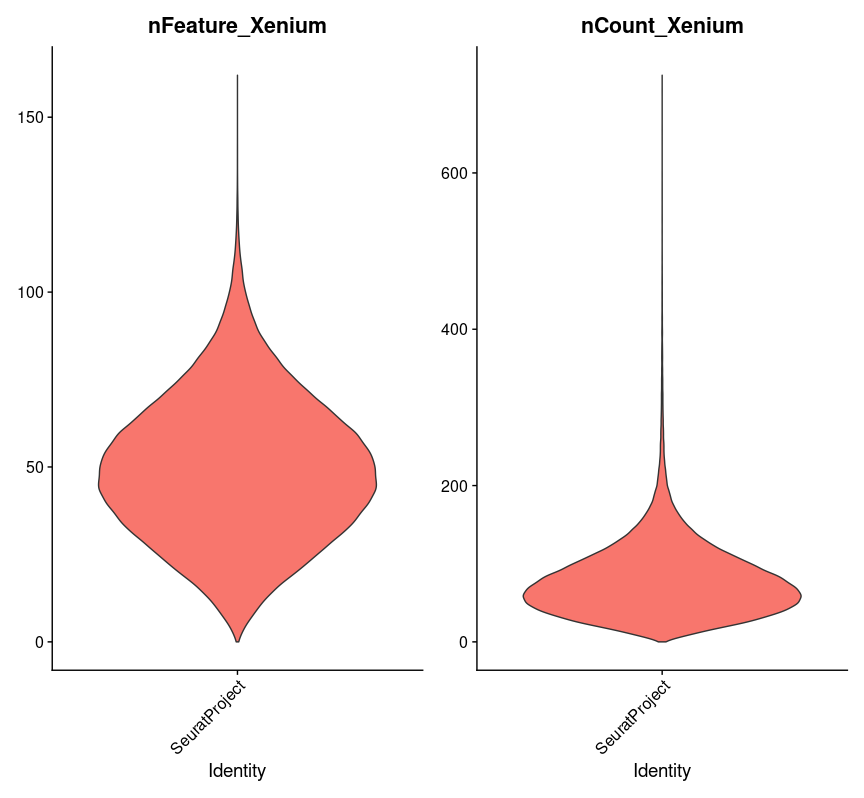

Violin Plots

```r
# QC plot
VlnPlot(xenium.obj, features = c("nFeature_Xenium", "nCount_Xenium"), ncol = 2, pt.size = 0)
```

**Explanation of parameters:**

- `features = c("nFeature_Xenium", "nCount_Xenium")`: Specifies the metadata columns to plot.
- `ncol = 2`: Arranges the two violin plots side-by-side in two columns.
- `pt.size = 0`: Hides individual data points within the violin plots. This is often preferred for large datasets to prevent overplotting and to focus on the overall distribution.

**Interpreting the QC Plots:**

By performing and interpreting these QC steps, you ensure that your downstream analyses are based on robust and biologically meaningful data. More information about QC in xenium analysis using Seurat pipeline can be found in **Seurat’s Mouse Brain: 10x Genomics Xenium in Situ vignette** `https://satijalab.org/seurat/articles/seurat5_spatial_vignette_2#mouse-brain-10x-genomics-xenium-in-situ`

## Data Exploration in Spatial Context

With the initial data loaded and quality checked, the next exciting step is to explore the gene expression patterns directly within their spatial context. This is where spatial transcriptomics truly shines, allowing us to visualize how specific genes are distributed across the tissue and identify potential regions of interest.

### Visualizing Molecules and Gene Expression Spatially

One of the most intuitive ways to explore spatial transcriptomics data is to overlay gene expression onto the tissue image. This allows us to observe if certain genes are enriched in specific anatomical structures or cell types. We can focus on genes that are known markers for particular cell types or cellular processes relevant to the tissue being studied (e.g., lung tissue in this example).

Here are some examples of well-known marker genes for various cell types in lung tissue:

- **`CNN1` (Calponin 1)**: A marker gene typically associated with **vascular smooth muscle cells**. Its spatial distribution can highlight blood vessel structures.
- **`LGR6` (Leucine-rich repeat-containing G protein-coupled receptor 6)**: A marker for **airway smooth muscle cells**, indicating the presence of bronchioles and airways.
- **`AGER` (Advanced Glycation End-product Specific Receptor)**: A classic marker for **alveolar type 1 (AT1) cells**, which are flat, squamous cells forming the primary gas exchange surface in the alveoli.
- **`SFTPD` (Surfactant Protein D)**: A key marker for **alveolar type 2 (AT2) cells**, cuboidal cells responsible for producing surfactant and acting as progenitor cells for AT1 cells.
- **`MUC5B` (Mucin 5B, Oligomeric Mucus/Gel-forming)**: A gene encoding a mucin protein, highly expressed in **goblet cells**, which are responsible for mucus production in the airways.
- **`SPDEF` (SAM Pointed Domain Containing ETS Transcription Factor)**: Another marker gene associated with **goblet cells** and generally involved in secretory cell differentiation.

Seurat provides powerful functions for spatial visualization:

- `ImageDimPlot()`: This function is used to visualize the spatial distribution of *individual molecules* for specified genes. It plots points representing individual transcripts on the spatial image. This provides a very granular view of gene localization.
- `ImageFeaturePlot()`: This function visualizes the *expression levels* of specific genes as a continuous color gradient (heatmap) overlaid on the spatial image. This provides a more smoothed representation of gene expression patterns across cells or regions.

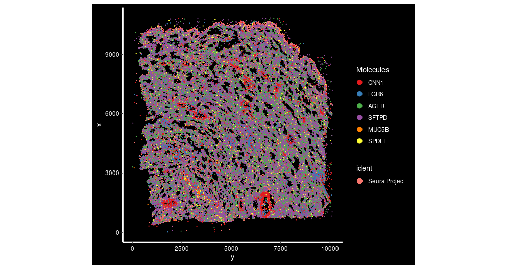

markers

```r
molecules.of.interest <- c("CNN1", "LGR6", "AGER", "SFTPD", "MUC5B", "SPDEF") # Defines the list of genes to visualize.
ImageDimPlot(xenium.obj, fov = "fov", molecules=molecules.of.interest, nmols = 20000, border.size = NA, group.by=NULL, axes = T)
ImageFeaturePlot(xenium.obj, features = molecules.of.interest, max.cutoff = c(25,35, 12, 10), size = 0.75, cols = c("white", "red"), border.size = NA)
```

In this spatial map, each dot marks the precise location of a single RNA molecule for one of six canonical lung marker genes, plotted against the tissue’s x–y coordinates. **CNN1** transcripts (red) trace out blood vessel and smooth‐muscle regions, while **LGR6** (blue) dots cluster around airway epithelia and bronchiolar structures. **AGER** (green) and **SFTPD** (purple) together outline the alveolar network—AGER on the flattened type I surfaces and **SFTPD** in surfactant‐producing cells—forming a dense mesh across the parenchyma. **MUC5B** (orange) highlights mucus‐secreting cells lining the larger airways, and **SPDEF** (yellow) marks secretory‐lineage zones. The contrast of brightly colored points against the black background makes it easy to visually distinguish these cell‐type–specific niches and appreciate the fine-grained molecular architecture of the lung tissue.

**Detailed explanation of parameters for `ImageDimPlot` and `ImageFeaturePlot`:**

- `fov = "fov"`: Specifies that the “field of view” image associated with the Seurat object should be used for the spatial background.
- `molecules=molecules.of.interest`: In `ImageDimPlot`, this argument takes a character vector of gene names. For each gene, individual detected RNA molecules are plotted as small points at their spatial coordinates.
- `nmols = 20000`: In `ImageDimPlot`, this sets a maximum number of molecules to plot for each gene. For very highly expressed genes, plotting every single molecule can lead to extreme overplotting and a cluttered image. This parameter helps to subsample and make the visualization clearer.
- `border.size = NA`: Controls the size of the border around each cell boundary. Setting it to `NA` removes the cell borders, which can be useful when plotting many molecules or features to avoid visual clutter.
- `group.by = NULL`: In `ImageDimPlot`, this would normally group cells by a metadata variable (e.g., cluster). Setting it to `NULL` means no grouping is applied, and the plot focuses on molecule locations.
- `axes = T`: Displays X and Y axes on the plot, indicating spatial coordinates.
- `features = molecules.of.interest`: In `ImageFeaturePlot`, this takes a character vector of gene names. The expression level of each gene in each cell is mapped to a color intensity.
- `max.cutoff = c(25,35, 12, 10)`: This is an important parameter for `ImageFeaturePlot` that controls the upper limit of the color scale for each feature. The values provided (`25`, `35`, `12`, `10` etc., should match the length of `molecules.of.interest`) act as the maximum expression value that will be mapped to the highest color intensity (e.g., “red” in `cols = c("white", "red")`). Any expression value above this cutoff will also be colored at the maximum intensity. This is useful for:
  - **Handling outliers**: Preventing a few highly expressing cells from compressing the color scale for the majority of cells.
  - **Visualizing dynamic range**: Emphasizing differences in expression among moderately expressing cells.
  - **Improving comparability**: Making plots for different genes more visually comparable if their absolute expression ranges vary greatly. You might need to adjust these values based on your specific dataset’s expression range to get optimal visualization.
- `size = 0.75`: Controls the size of the points representing cells in `ImageFeaturePlot`.
- `cols = c("white", "red")`: Defines the color gradient for expression levels, typically from a low-expression color (e.g., white or light grey) to a high-expression color (e.g., red or blue).

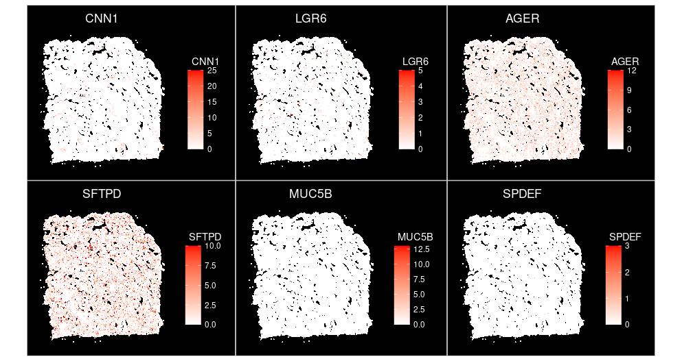

markers2

These plots are useful for generating hypotheses about cell type locations, tissue architecture, and the spatial distribution of biological processes. For example, you might observe `CNN1` expression forming ring-like structures indicative of blood vessels, while `AGER` and `SFTPD` show more diffuse but distinct patterns in alveolar regions.

## Normalization, Dimensionality Reduction, and Clustering

After exploring the raw and spatially-mapped data, the next sequence of steps aims to transform the complex gene expression data into a more manageable and interpretable format. This involves normalization to account for technical variations, dimensionality reduction to simplify the data while retaining biological signals, and clustering to group similar cells.

### Normalization using SCTransform

**Normalization** is a critical preprocessing step that adjusts raw gene expression counts to account for technical differences between cells, such as variations in sequencing depth or capture efficiency. Without proper normalization, these technical biases could be misinterpreted as biological differences.

The `SCTransform()` function in Seurat is a robust and widely recommended method for normalizing single-cell and spatial transcriptomics data. It addresses some limitations of traditional normalization methods by:

- **Modeling Gene Expression**: `SCTransform` models gene expression as a function of sequencing depth (the total number of molecules detected in a cell). It uses a regularized negative binomial regression model, which is well-suited for count data.
- **Pearson Residuals**: Instead of simply dividing by total counts, `SCTransform` calculates Pearson residuals from this regression model. These residuals represent how much a gene’s expression deviates from what would be expected given the sequencing depth, effectively removing the technical noise associated with library size.
- **Information Pooling (Regularization)**: To prevent overfitting, especially for genes with low expression, `SCTransform` pools information across genes that are expressed at similar levels. This regularization makes the variance estimation more stable and accurate.
- **Output**: The `SCTransform` function stores the normalized and scaled data in the `SCT` assay within the Seurat object. This assay is then used for subsequent dimensionality reduction and clustering steps.

For larger datasets, memory can be a constraint. The `options(future.globals.maxSize = 1024 * 1024 * 1024)` command increases the maximum size of global objects that can be used by the `future` package (which `SCTransform` relies on for parallel processing), setting it to 1 Gigabyte (1 GiB). This helps prevent “node stack overflow” or memory allocation errors during the transformation.

```r
options(future.globals.maxSize = 1024 * 1024 * 1024)  # 1 GiB
xenium.obj <- SCTransform(xenium.obj, assay = "Xenium")
```

The `assay = "Xenium"` argument explicitly tells `SCTransform` to operate on the raw counts within the “Xenium” assay slot of your Seurat object.

### Dimensionality Reduction: PCA and UMAP

Even after normalization, gene expression data remains high-dimensional (hundreds of genes). Visualizing and analyzing these data directly is challenging. **Dimensionality reduction** techniques simplify the data by projecting it into a lower-dimensional space while preserving the most significant biological variations.

1. **Principal Component Analysis (PCA)**:
   - **Purpose**: PCA is a linear dimensionality reduction technique that transforms the data into a new coordinate system where the first dimension (principal component, PC1) captures the largest variance in the data, the second dimension (PC2) captures the second largest variance, and so on. These principal components are orthogonal (uncorrelated) to each other.
   - **Application**: `RunPCA()` is applied to the scaled data (from `SCTransform`). The `npcs` parameter specifies how many principal components to compute. A common practice is to choose `npcs` around 30-50.
2. **Uniform Manifold Approximation and Projection (UMAP)**:
   - **Purpose**: UMAP is a non-linear dimensionality reduction technique. Unlike PCA, which aims to capture global variance, UMAP focuses on preserving the local and global structure of the data manifold. It is particularly effective at visualizing high-dimensional data in two or three dimensions, often revealing distinct clusters of cells.
   - **Application**: `RunUMAP()` is performed using the principal components calculated from PCA (`dims = 1:npcs`). The UMAP projection is stored in the `reductions` slot of the Seurat object and is commonly used for visualizing cell populations.

```r
npcs <- 30 # Number of principal components to use for dimensionality reduction and subsequent clustering.
xenium.obj <- RunPCA(object = xenium.obj, npcs=npcs)
xenium.obj <- RunUMAP(xenium.obj, dims = 1:npcs)
```

The choice of `npcs` (number of principal components) is important. Using too few might discard important biological variation, while using too many might incorporate noise. An Elbow Plot (generated by `ElbowPlot(xenium.obj)`) can help identify the “elbow” point where adding more PCs yields diminishing returns in explained variance, suggesting an optimal number.

### Clustering with Leiden Algorithm

**Clustering** is the process of grouping cells that have similar gene expression profiles. These groups are often interpreted as distinct cell types, cell states, or subpopulations within the tissue. Seurat uses a graph-based clustering approach:

The following code demonstrates testing different `resolution` values and visualizing the results on the UMAP plot:

```r
xenium.obj <- FindNeighbors(xenium.obj, reduction = "pca", dims = 1:npcs)

# Clustering with resolution 0.1: Often yields very broad clusters.
xenium.obj <- FindClusters(xenium.obj, resolution = 0.1)
DimPlot(xenium.obj, raster=F) # Visualize clusters on UMAP. `raster=F` ensures high-quality vector graphics for smaller datasets or if explicit points are desired.

# Clustering with resolution 1.0: Likely to yield many fine-grained clusters.
xenium.obj <- FindClusters(xenium.obj, resolution = 1.0)
DimPlot(xenium.obj, raster=F) # Visualize clusters on UMAP.

# Clustering with resolution 0.3: Often a good balance and a common starting point for many datasets.
xenium.obj <- FindClusters(xenium.obj, resolution = 0.3)
DimPlot(xenium.obj, raster=F) # Visualize clusters on UMAP.
```

Each `DimPlot` will display the UMAP projection, with each cell colored according to its assigned cluster. By comparing these plots, you can visually assess how different resolutions impact the cell groupings. The goal is to identify a resolution that provides a biologically meaningful separation of cell populations, avoiding both over-clustering (too many fragmented groups) and under-clustering (merging distinct cell types).

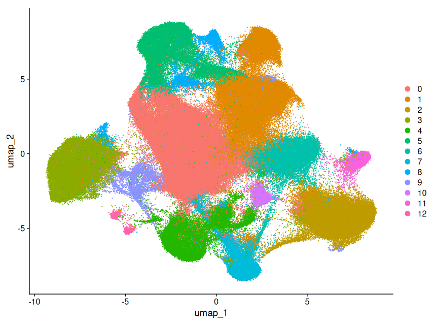

umap

In this case, the UMAP projection reveals thirteen distinct clusters (0–12), each forming coherent “islands” in low-dimensional space. The smooth boundaries between some clusters and sharp gaps between others reflect both continuum transitions and clear lineage bifurcations in the lung’s cellular landscape. This spatial visualization is a powerful way to interpret the biological meaning of your clusters and to generate hypotheses about tissue organization and function.

### Visualizing Marker Gene Expression on UMAP

To further validate the biological relevance of the clusters, it’s insightful to overlay the expression levels of known marker genes (e.g., `molecules.of.interest` defined earlier) onto the UMAP projection. This helps to confirm if specific marker genes are highly expressed within particular clusters, providing preliminary evidence for their identity.

```r
FeaturePlot(xenium.obj, features = molecules.of.interest, raster=F)
```

**Explanation of parameters:**

- `features = molecules.of.interest`: Specifies the genes whose expression levels will be visualized.
- `raster=F`: Ensures that the UMAP plot is rendered as individual points rather than a raster image. This maintains clarity and detail, especially for smaller datasets or when exporting to vector formats. For very large datasets, `raster=T` might be necessary for performance.

If your clustering is effective and biologically meaningful, you should observe that cells within certain clusters show higher expression of specific marker genes. For example, a cluster potentially representing alveolar type 2 cells should show high `SFTPD` expression, while other clusters show low expression. This visual validation strengthens your confidence in the identified clusters.

### Visualizing Clusters in the Spatial Domain

While UMAP plots help to visualize clusters in an abstract, reduced-dimensional space, it is crucial for spatial transcriptomics to map these identified clusters back onto the original tissue image. This step provides critical spatial context and reveals how different cell populations are organized within the tissue architecture.

[figure not shown]

umap_markers

```r
ImageDimPlot(xenium.obj, cols = "polychrome", size=0.75, border.size = NA)
```

[output not shown]

**Explanation of parameters:**

- `cols = "polychrome"`: Specifies a color palette to use for coloring the clusters. “Polychrome” is a divergent palette that provides many distinct colors, which is useful when you have a large number of clusters.
- `size = 0.75`: Controls the size of the points representing each cell on the spatial image. Adjust this value to ensure cells are clearly visible without excessive overlap.
- `border.size = NA`: As before, setting this to `NA` removes the borders around cells, which can improve visualization, especially with dense cellular regions.

This `ImageDimPlot` will show your tissue section with each cell colored according to its assigned cluster ID. This allows for direct observation of:

- **Spatial Segregation**: Do certain clusters occupy distinct anatomical regions (e.g., clusters forming blood vessel structures, or distinct regions for bronchioles vs. alveoli)?
- **Intermixing**: Are different cell types intermixed in certain areas, suggesting specific cellular interactions or transitional states?
- **Concordance with Morphology**: Do the cluster boundaries align with visible morphological features in the underlying tissue image (if available or mentally overlaid)?

## Identifying Cluster-Specific Differentially Expressed Genes (DEGs)

Once cells are grouped into clusters, a key analytical step is to identify genes that are differentially expressed (DE) in each cluster compared to all other clusters. These **cluster-specific DEGs** serve as potential marker genes that help define the unique molecular identity of each cell population. They are crucial for subsequent biological interpretation and cluster annotation.

### Finding All Cluster Markers

The `FindAllMarkers()` function in Seurat is designed to systematically identify DEGs for all clusters. For each cluster, it compares its gene expression profile against all other cells in the dataset (or a subset of them).

```r
# Identify cluster markers
cluster.markers <- FindAllMarkers(xenium.obj, only.pos = TRUE)
cluster.markers %>%
  group_by(cluster) %>%
  dplyr::filter(avg_log2FC > 1)
```

**Detailed explanation of parameters and output:**

The resulting filtered table provides a list of candidate marker genes for each of your identified clusters, ranked by their differential expression.

### Visualizing Expression Distributions of Marker Genes

To visually confirm the differential expression patterns of specific genes identified as markers, violin plots are an excellent tool. They show the distribution of gene expression levels across all clusters, allowing you to see if a gene is indeed highly expressed in one or a few specific clusters and lowly expressed elsewhere.

```r
# Visualize expression for certain cluster markers
markers <- c()
VlnPlot(xenium.obj, features = c("SHANK3", "SFTPD"), raster=F)
```

**Explanation of parameters:**

- `features = c("SHANK3", "SFTPD")`: Specifies the genes for which violin plots will be generated. You should replace `"SHANK3"` and `"SFTPD"` with genes you’ve identified as strong markers from your `FindAllMarkers` output (e.g., from the `top10` list in the next section).
- `raster=F`: Ensures the plots are rendered with individual points, which can be useful for visualizing raw data distribution, though for very large datasets, `raster=T` might be faster.

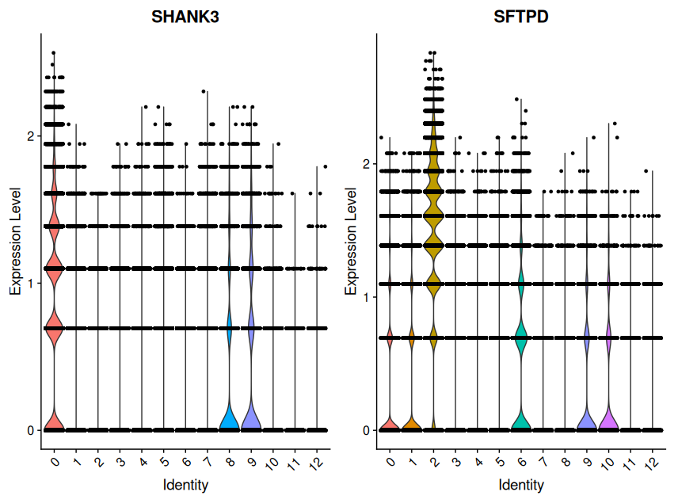

violin

### Generating an Expression Heatmap of Top Markers

A heatmap provides a compact and powerful way to visualize the expression patterns of multiple marker genes across all identified clusters simultaneously. It allows for quick identification of gene sets that define each cluster.

```r
# Generate heatmap based on the cluster markers
cluster.markers %>%
  group_by(cluster) %>%
  dplyr::filter(avg_log2FC > 1) %>%
  slice_head(n = 10) %>%
  ungroup() -> top10
DoHeatmap(subset(xenium.obj, downsample = 100), features = top10$gene) + NoLegend() # subset number of spots, given that this function does not work with > 30.000 spots
```

**Detailed explanation of the `dplyr` pipeline for `top10` and `DoHeatmap`:**

1. `cluster.markers %>% group_by(cluster) %>% ...`: Starts with the `cluster.markers` data frame and groups it by the `cluster` column. This means subsequent operations will be applied independently to each cluster’s markers.
2. `dplyr::filter(avg_log2FC > 1)`: Filters within each cluster group to keep only genes with an `avg_log2FC` greater than 1 (i.e., at least 2-fold upregulated).
3. `slice_head(n = 10)`: For each grouped cluster, this selects the top 10 genes. By default, `slice_head` will select the first 10 rows, and since `FindAllMarkers` generally orders by `avg_log2FC` and `p_val_adj`, this effectively selects the top 10 strongest markers.
4. `features = top10$gene`: This argument to `DoHeatmap` tells it to plot the expression of all the gene names contained in the `gene` column of the `top10` data frame.

Then plots a heatmap of those marker genes’ expression across a downsampled set of spots (≤100 per cluster) without showing the legend.

**`DoHeatmap()` Function:**

- `subset(xenium.obj, downsample = 100)`: This is a critical optimization for large datasets. `DoHeatmap` can be computationally intensive and visually cluttered with thousands of cells. `downsample = 100` randomly selects 100 cells from *each* cluster. This significantly reduces the number of cells plotted while still representing the overall expression patterns of each cluster. If your dataset is smaller (e.g., a few thousand cells total), you might omit the `downsample` argument or choose a higher number.
- `features = top10$gene`: Specifies which genes to include in the heatmap (the top 10 markers for each cluster).
- `+ NoLegend()`: Removes the legend from the plot, which can sometimes be redundant or visually distracting in heatmaps of this type.

The heatmap will typically display cells (downsampled) on the X-axis and the top marker genes on the Y-axis. The color intensity in each cell will represent the expression level of a gene, and distinct blocks of high expression will correspond to the marker genes for each cluster. This visualization allows for a rapid assessment of cluster homogeneity and the distinctiveness of their molecular profiles.

[figure not shown]

## Cluster Annotation

The final and arguably most biologically significant step is to assign meaningful biological labels (e.g., specific cell types) to the identified clusters. This transforms abstract cluster IDs into interpretable biological entities, linking your computational findings to known biology.

### Annotating Clusters using Gene Panel Information

We leverage the gene panel annotation file (loaded as `anno.dat` earlier), which often provides pre-defined cell type annotations for specific genes, usually provided by the technology vendor (e.g., 10x Genomics for their Xenium human lung panel). The strategy here is to use a “majority voting” approach: for each cluster, we examine the cell type annotations of its top marker genes and assign the cluster the cell type that is most frequently associated with those markers.

```r
# Retrieve the gene panel annotation provided by 10X and merge this information with the cluster markers
anno.dat <- merge(cluster.markers, anno.dat[,c("Gene", "Annotation")], by.x="row.names", by.y="Gene")
```

**Explanation of the merge step:**

- We take the `cluster.markers` data frame (which contains the differentially expressed genes for each cluster).
- We `merge` it with the `anno.dat` data frame.
- `by.x="row.names"`: Specifies that the merge should occur based on the row names of `cluster.markers` (which are the gene names).
- `by.y="Gene"`: Specifies that the merge should occur based on the “Gene” column in `anno.dat`.
- `anno.dat[,c("Gene", "Annotation")]`: We select only the “Gene” and “Annotation” columns from the original `anno.dat` to ensure a clean merge. The result is an `anno.dat` data frame that now includes `cluster` information alongside `Gene` and `Annotation` for all identified markers.

```r
# Determine for each cluster the most prominent annotation by majority voting
cluster.names <- sapply(unique(cluster.markers$cluster), function(x) names(which.max(table(anno.dat$Annotation[anno.dat$cluster == x]))))
cluster.names[sapply(cluster.names, is.null)] <- NA
```

**Explanation of majority voting:**

1. `unique(cluster.markers$cluster)`: Gets all unique cluster IDs.
2. `sapply(..., function(x) ...)`: Applies a function to each unique cluster ID (`x`).
3. `anno.dat$Annotation[anno.dat$cluster == x]`: For the current cluster `x`, this extracts all the “Annotation” labels associated with its marker genes (from the merged `anno.dat`).
4. `table(...)`: Counts the occurrences of each unique annotation label within that cluster’s markers.
5. `which.max(table(...))`: Finds the annotation label with the highest count (the “majority vote”).
6. `names(which.max(...))`: Extracts the actual name of that majority annotation.
7. `cluster.names[sapply(cluster.names, is.null)] <- NA`: This line handles cases where a cluster might not have any markers with a corresponding annotation in the `anno.dat` file (resulting in `NULL` for that cluster’s name). It replaces `NULL` entries with `NA`. The `cluster.names` object will be a named vector where the names are the original cluster IDs and the values are the newly assigned cell type annotations.

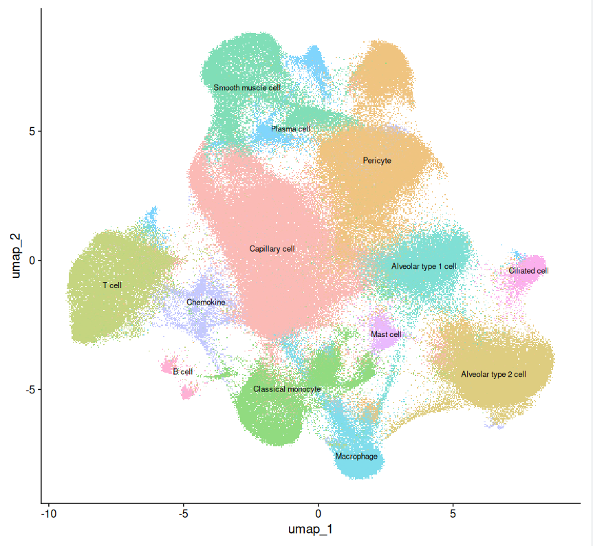

umap_anno

```r
# Add new cluster names to Seurat object and plot UMAP with annotation
names(cluster.names) <- levels(xenium.obj)
xenium.obj <- RenameIdents(xenium.obj, cluster.names)
DimPlot(xenium.obj, reduction = "umap", label = TRUE, label.size=3, pt.size = 0.5) + NoLegend()
```

The fully annotated UMAP brings together our clustering and marker‐based insights to assign putative cell identities across the lung atlas. The annotated map provides an intuitive spatial overview for selecting cluster‐specific markers, designing targeted validations, and exploring intercellular interactions in situ. From here, you can readily perform differential expression analyses between any two clusters to uncover unique gene programs, and even apply cell‑to‑cell communication tools (e.g., ligand‑receptor inference) to predict how these populations interact within the lung microenvironment.

**Updating and plotting the Seurat object:**

1. `names(cluster.names) <- levels(xenium.obj)`: Ensures that the names of the `cluster.names` vector (which are the old cluster IDs) correctly correspond to the `levels` (the order of factors) in the Seurat object’s identity classes.
2. `xenium.obj <- RenameIdents(xenium.obj, cluster.names)`: This crucial function updates the `ident` slot (the active identity of cells) in the Seurat object with your newly derived cell type annotations. Now, `Idents(xenium.obj)` will return the cell type names instead of numerical cluster IDs.
3. `DimPlot(xenium.obj, reduction = "umap", label = TRUE, label.size=3, pt.size = 0.5) + NoLegend()`:
   - `reduction = "umap"`: Specifies that the UMAP dimensionality reduction should be used for the plot.
   - `label = TRUE`: Displays the cluster labels (now cell type names) directly on the UMAP plot.
   - `label.size=3`: Sets the size of the cluster labels.
   - `pt.size = 0.5`: Sets the size of the points representing individual cells.
   - `+ NoLegend()`: Removes the default legend, as the labels directly on the plot make it redundant and often clearer.

This final `DimPlot` provides the most interpretable visualization of your analysis: a UMAP projection where cells are colored and labeled by their predicted cell type, derived directly from their gene expression profiles and integrated gene panel annotations. This plot is essential for communicating your findings about the cellular composition and heterogeneity of your spatial transcriptomics sample.

## Saving Results

The final step in the workflow is to save your fully processed Seurat object. This is a critical practice for reproducibility, collaboration, and for enabling further downstream analysis without needing to re-run the entire pipeline from scratch.

### Saving the Seurat Object

In the context of a Galaxy workflow, the `gx_put()` function is used to output the processed object, making it available in your Galaxy history.

```r
gx_put(xenium.obj)
```

- `gx_put(xenium.obj)`: This command takes the `xenium.obj` (your Seurat object) and writes it to a file that becomes an output dataset in your Galaxy workflow history. This file is typically in a format that Seurat can easily read back in (e.g., an RDS file, which is an R serialized object).

**Important Note for Non-Galaxy Users:** If you are running this R Markdown script outside of the Galaxy environment, you would use the standard R function `saveRDS()` to save your Seurat object to a file on your local system:

```r
# For non-Galaxy environments:
# saveRDS(xenium.obj, file = "my_xenium_seurat_object_processed.rds")
```

To load this object back into an R session later, you would use `readRDS()`:

```r
# For non-Galaxy environments:
# loaded_xenium.obj <- readRDS("my_xenium_seurat_object_processed.rds")
```

Saving the object ensures that all the normalization, dimensionality reduction, clustering, and annotation steps are preserved, allowing you or others to pick up the analysis from this point without repeating the computationally intensive upstream steps.

This concludes the detailed tutorial for analyzing 10x Xenium spatial transcriptomics data using Seurat. You now have a comprehensive understanding of each step, from raw data import to biological interpretation and final saving of results.